# Forecasting The Houston Rockets Wins

## Introduction

The Houston Rockets are one of the premier NBA franchises. Last season, they led the league in number of wins with 65. They were also one of the top playoff performers as well, finishing in the top four teams. They seem to have a bright future, and should be considered a top threat to win the NBA championship. One of the ways we can confirm this is to forecast the number of wins over the next few seasons. If the number of wins remain high, then we know that the team is still a top team. Using data from BasketballReference.com, we will forecast the number of wins and win percentage for the Rockets over the next 3 seasons.

## Results

First we will set our working directory.

```r
setwd("~/Desktop/Summer Project #1")
```

Next we will load our libraries.

```r
library(lattice)
library(foreign)
library(MASS)
library(car)
require(stats)
require(stats4)
library(KernSmooth)
library(fastICA)
library(cluster)
library(leaps)
library(mgcv)
library(rpart)
library(pan)
library(mgcv)
library(DAAG)
library("TTR")
library(tis)
```

```r
require("datasets")
require(graphics)
library("forecast")
#install.packages("astsa")
#require(astsa)
library(nlstools)
library(fpp)
library(strucchange)
library(Quandl)
library(zoo)
library(PerformanceAnalytics)
library(quantmod)
#library(stockPortfolio)
library(vars)
library(lmtest)
library(dlnm)
library(hts)
library(tseries)
library(rugarch)
```

Now we will load in the data.

```r
library(readxl)
houston_rockets_wins <- read_excel("Summer Project #1 Data.xlsx")
View(houston_rockets_wins)
```

First we will generate a time series of the number of wins per season.

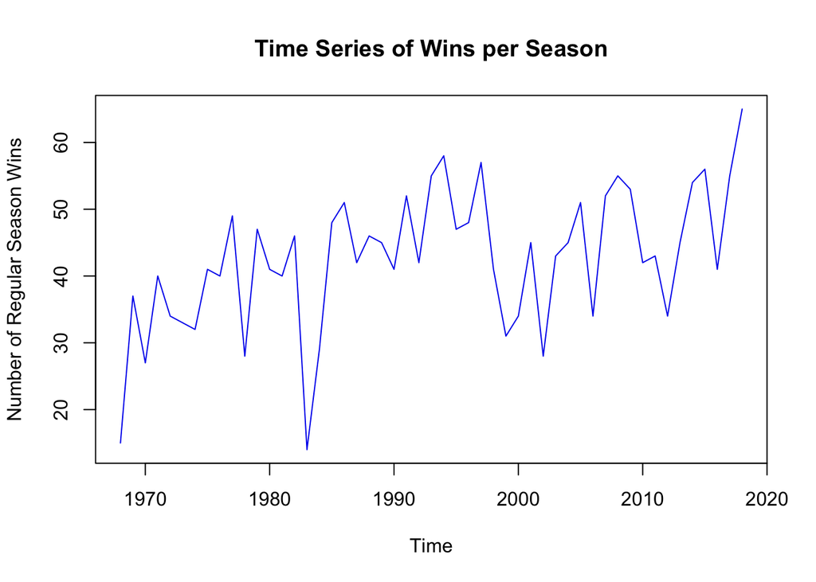

```r
wins_ts <- ts(houston_rockets_wins$W, start = 1968, frequency = 1)
plot(wins_ts, xlab = "Time", ylab = "Number of Regular Season Wins", main = "Time Series of Wins per Season", col = "blue2")
```

We will also plot a time series of the first order difference. We do this because we want to work with covariance stationary data. Unfortunately the data above is not covarince stationary. We confirm this with the Augmented Dickey-Fuller Test. Looking at the time series further, we see that there seems to be an upward trend. Judging by the context of the data, there is probably no seasonality.

```r
adf.test(wins_ts, alternative = "stationary", k = 20)
```

```
##
##  Augmented Dickey-Fuller Test
##
## data:  wins_ts
## Dickey-Fuller = -1.9834, Lag order = 20, p-value = 0.5811
## alternative hypothesis: stationary
```

The high p-value of .5811 confirms that we the data is not stationary. We will now define the first order difference and generate a time series of first order difference wins.

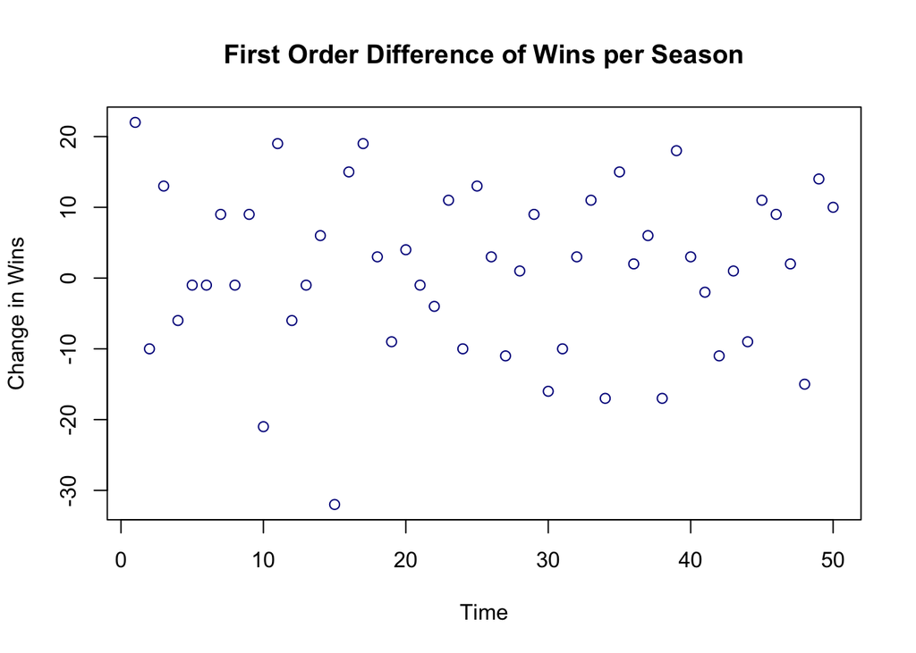

```r
library(ggplot2)
first_order_wins <- diff(houston_rockets_wins$W)
first_order_ts <- ts(first_order_wins, start = 1968, frequency = 1)
plot(first_order_wins, xlab = "Time", ylab = "Change in Wins", main = "First Order Difference of Wins per Season", col = "blue4")
```

The results seem to be centered around zero and the data looks covariance stationary. For completeness, we will generate a time series of the win percentage.

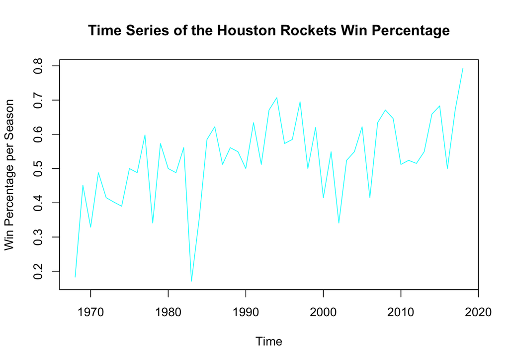

```r
win_percentage_ts <- ts(houston_rockets_wins$`W/L%`, start = 1968, frequency = 1)
plot(win_percentage_ts, ylab = "Win Percentage per Season", main = "Time Series of the Houston Rockets Win Percentage", col = "cyan")
```

We will also generate the ACF and PACF of the Number of Wins Per Season. The ACF allows us to tell how much the number of wins in the current season depends on the number of wins in the previous seasons. This will allow us to examine any cyclical movements in the data as well. Intuitively, we expect that the ACF will decay to zero as the number of wins in the current season may depend on the number of wins in the previous season or perhaps the season before the previous season, but probably wont depend on the number of wins from 11 or 12 seasons ago. We will also generate the ACF and PACF of the first order difference as the first order difference data is stationary.

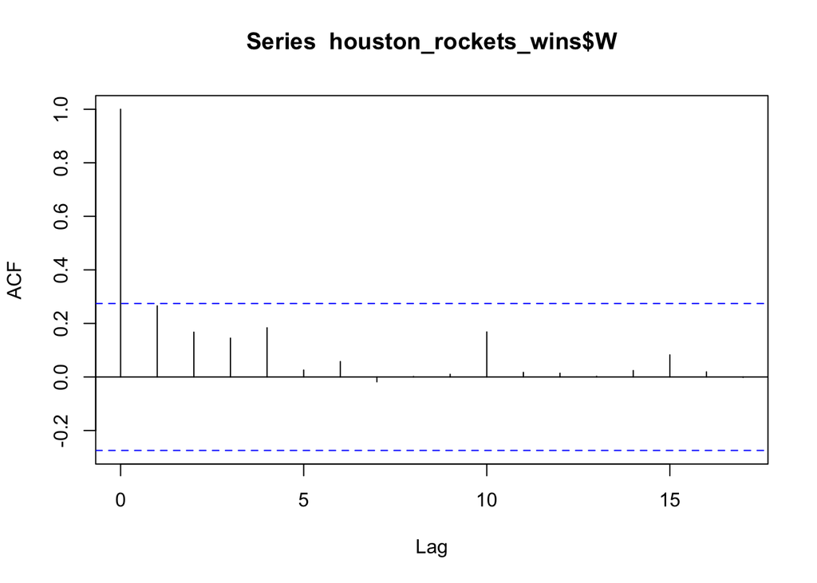

```r
acf(houston_rockets_wins$W)
```

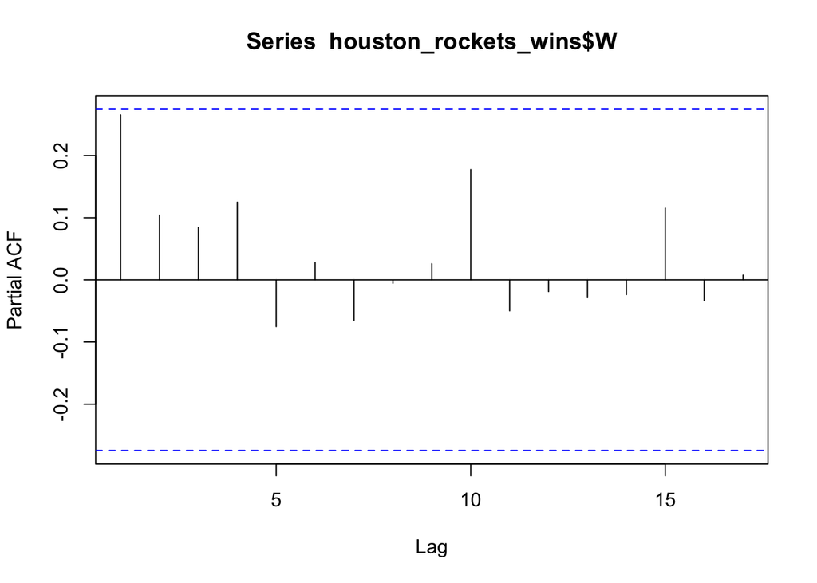

```r
pacf(houston_rockets_wins$W)
```

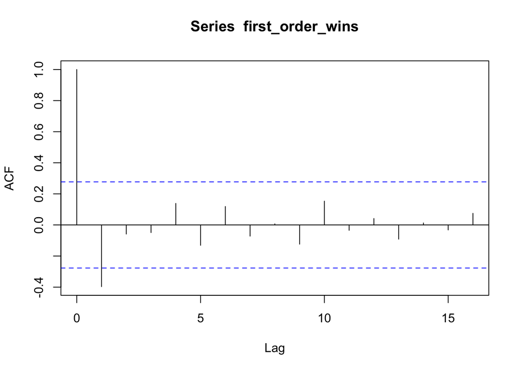

```r
acf(first_order_wins)
```

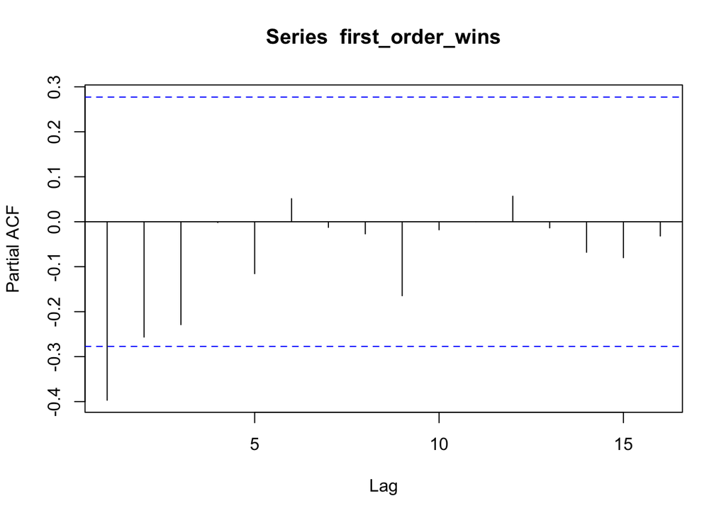

```r
pacf(first_order_wins)
```

```r
arima(wins_ts, order = c(1,1,0))
```

```
##
## Call:
## arima(x = wins_ts, order = c(1, 1, 0))
##
## Coefficients:
##           ar1
##       -0.4188
## s.e.   0.1330
##
## sigma^2 estimated as 112.6:  log likelihood = -189.13,  aic = 382.27
```

```r
arima(wins_ts, order = c(2,1,0))
```

```
##
## Call:
## arima(x = wins_ts, order = c(2, 1, 0))
##
## Coefficients:
##           ar1      ar2
##       -0.5429  -0.2925
## s.e.   0.1418   0.1428
##
## sigma^2 estimated as 103.6:  log likelihood = -187.14,  aic = 380.27
```

```r
arima(wins_ts, order = c(3,1,0))
```

```
##
## Call:
## arima(x = wins_ts, order = c(3, 1, 0))
##
## Coefficients:
##           ar1      ar2      ar3
##       -0.6293  -0.4396  -0.2826
## s.e.   0.1434   0.1566   0.1448
##
## sigma^2 estimated as 95.83:  log likelihood = -185.32,  aic = 378.64
```

```r
arima(wins_ts, order = c(4,1,0))
```

```
##
## Call:
## arima(x = wins_ts, order = c(4, 1, 0))
##
## Coefficients:
##           ar1      ar2      ar3      ar4
##       -0.6357  -0.4498  -0.2961  -0.0223
## s.e.   0.1496   0.1711   0.1709   0.1498
##
## sigma^2 estimated as 95.79:  log likelihood = -185.31,  aic = 380.62
```

Here we see that the ARIMA(3,1,0) model has the smallest AIC value. This makes sense since we saw that the PACF of the first order difference has 3 rather large spikes. We will forecast with this model. However before forecasting, we will run diagnostics on this model.